# Step 6 Prey Trait Cluster Analyses

Similar to https://stackoverflow.com/questions/38034663/rotate-labels-for-ggplot-dendrogram

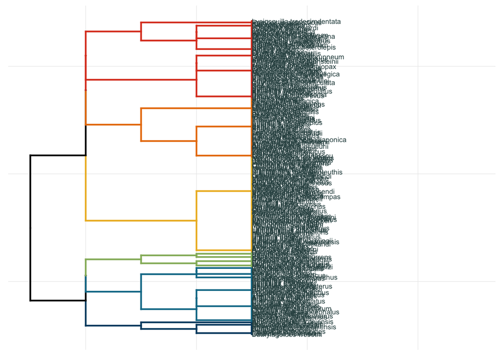

```r
# This is a different way to compute hierarchical clustering and cut the tree
#clus <- hcut(mydist, k = 6, hc_func = 'hclust', hc_method = 'ward.D2', graph = FALSE, isdiss = TRUE)

#Below is problematic0
#labels(dend) <- paste0(paste0(rep('', 3), collapse = ''), speciesO)
#dend <- sort(dend, decreasing = FALSE)
#View(labels(dend))

#Creating df for the dend labels so that we can accurately line them up with the species
dendlabs <- labels(prob.dendro) #Need to create strings of labels to manipulate
dendlabs2 <- as.data.frame(dendlabs) #turn in df

#Join these data so we can relabel the dendrogram
#Use plyr function because it conserves the row order of the left df, which matters for assigning labels here

dfdend <- join(dendlabs2, prey_traits)

ggd1 <- ggplot(prob.dendro %>%
                 set("branches_k_color", k = 6, value = PNW.pal6) %>%
                 set("branches_lwd", 0.8) %>%
                 set("labels", dfdend$prey_sp) %>% #NOT VERY LEGIBLE...
                 set("labels_colors",
                     value = c("darkslategray")) %>%
                 set("labels_cex", 0.5),
               theme = theme_minimal(),
               horiz = TRUE)

ggd1 <- ggd1 + theme(panel.grid.major = element_blank(),
                     axis.text = element_blank(),
                     axis.title = element_blank())
ggd1 <- ggd1 + ylim(max(get_branches_heights(prob.dendro)), -1)
ggd1
```

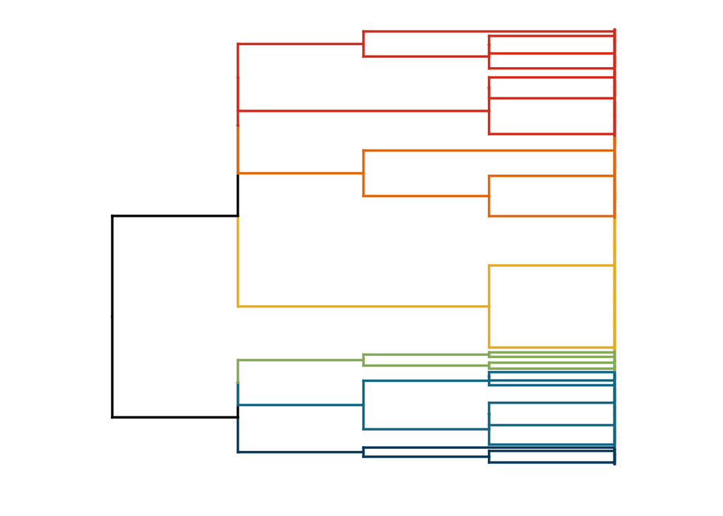

```r
ggsave(here('outputs_figures/clusters/prob_cluster_mar2022/div_hab/prob.dendro.vertlabs.k6.hab.pdf'), plot=ggd1, width=5, height=20, dpi=300)

#With labels removed!!!

prob.dendro.vert <- ggplot(prob.ggd1, horiz = TRUE, labels = FALSE) +
  scale_y_reverse(expand = c(0.2, 0)) #+
#coord_polar(theta="x")
prob.dendro.vert
```

```r
#Export as .png
ggsave(here('outputs_figures/clusters/prob_cluster_mar2022/div_hab/prob.dendro.vert2.k6.hab.png'), plot=prob.dendro.vert, width=5, height=12, dpi=300)
```

### Cluster Heatmaps

```r
#Extract cluster number to trait matrix
prob.clust.num <- cutree(prob.divisive.clust, k = 6)

#we want to bind the original dataset with the cluster numbers such that each species is assigned a cluster
#can use whole data or just traits use to just look at unique species clusters in relation to traits
#alb.cl <- cbind(ctraitsO, alb.clust.num)
#OR
prob.prey.cl <- cbind(prey_traits, prob.clust.num)

#View(prob.prey.cl)

write.csv(prob.prey.cl, here("outputs_figures/clusters/prob_cluster_mar2022/div_hab/prob.prey.clusternum.divis.k6.hab.csv"), row.names = FALSE)
```

```r
# Time for the heatmap
# the 1st step here is to have 1 variable per row
# factors have to be converted to characters in order not to be dropped

#Note plyr can mess with this!!
#detach("package:plyr", unload=TRUE)

#Create dfs for graphs
prob.clust.long = prob.prey.cl %>%
  dplyr::select(prey_sp, life_stage:season_cat, `gregarious`, `prob.clust.num`) %>% #maxFO:maxM,
  reshape2::melt(id.vars = c("prey_sp", "prob.clust.num"), variable.name = "trait", value.name = "level") %>%
  group_by(prob.clust.num, trait, level) %>%
  mutate(count = n_distinct(prey_sp)) %>%
  distinct(prob.clust.num, trait, level, count) %>% #, percent
  group_by(prob.clust.num, trait) %>%
  mutate(percent = count / sum(count)*100) %>%
  arrange(prob.clust.num)

#str(prob.clust.long)
```

```r
#heatmap.c will be suitable in case you want to go for absolute counts - but it doesn't tell much to my taste
#problem below involves the values of our data being ordinal, therefore they are not unique
levels(prob.clust.long$trait)
```

```
## [1] "life_stage"       "vert_habitat"     "horz_habitat"     "diel_migrant_cat"
## [5] "season_cat"       "gregarious"
```

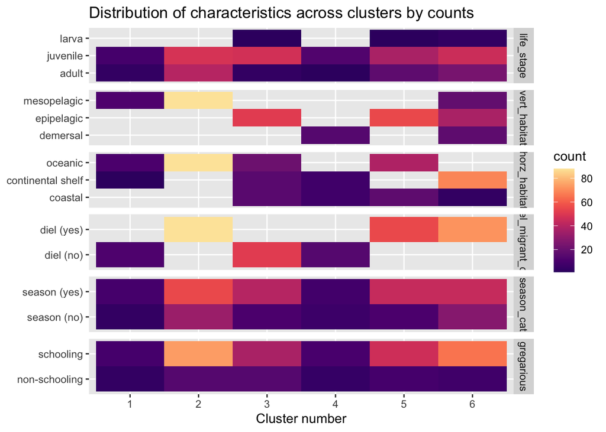

```r
#Our data above comes truncated, you would need to truncate the data and re-label clusters depending on which dfs you melt/merge/reshape.
#Example: View(alb.cust.long.q[96:nrow(alb.cust.long.q),])
heatmap.c <- ggplot(prob.clust.long, aes(x = factor(prob.clust.num), y = level)) +
  geom_tile(aes(fill = count))+
  labs(title = "Distribution of characteristics across clusters by counts", x = "Cluster number", y = NULL) +
  scale_fill_viridis(option="magma", begin = 0.2, end = 0.95)+
  facet_grid(trait~. , scales="free_y")
heatmap.c
```

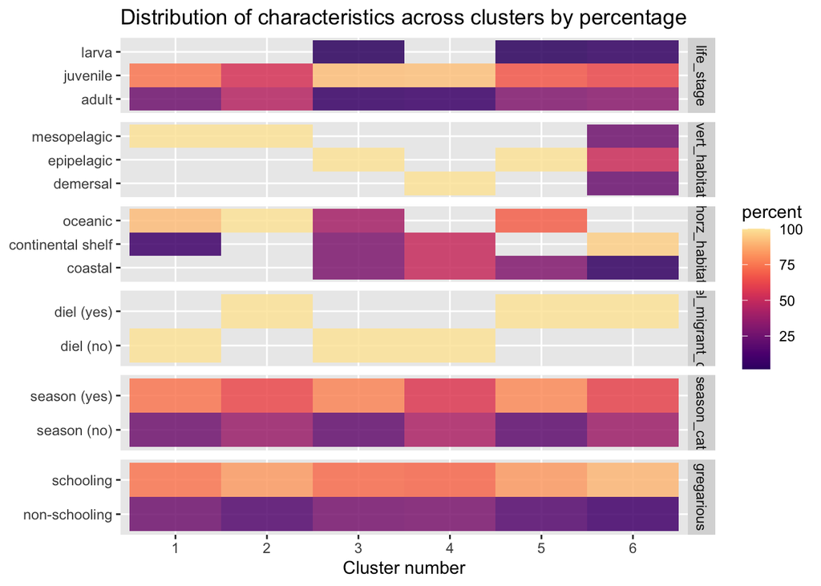

```r
ggsave(here('outputs_figures/clusters/prob_cluster_mar2022/div_hab/prob.dendro.heatcounts.divis.k6.hab.pdf'), plot=heatmap.c, width=8, height=12, dpi=300)


heatmap.p <- ggplot(prob.clust.long, aes(x = factor(prob.clust.num), y = factor(level, ordered = T))) +
  geom_tile(aes(fill = percent), alpha = 0.85)+
  labs(title = "Distribution of characteristics across clusters by percentage", x = "Cluster number", y = NULL) +
  #scale_fill_gradient2(low = "darkslategray1", mid = "yellow", high = "turquoise4") +
  scale_fill_viridis(option="magma", begin = 0.2, end = 0.95)+
  facet_grid(trait~., scales="free_y")
heatmap.p
```

```r
ggsave(here('outputs_figures/clusters/prob_cluster_mar2022/div_hab/prob.dendro.heatpercent.divis.k6.hab.pdf'), plot=heatmap.p, width=8, height=12, dpi=300)

#library(plyr)
```

```r
summary(as.factor(prob.prey.cl$prob.clust.num))
```

```
##  1  2  3  4  5  6
## 12 88 51 14 55 72
```

```r
# 1  2  3  4  5  6  7
#12 88 51 14 55 44 28

#With all variables, gregarious and life stage
#  1   2   3   4   5   6   7
# 54 138  11  29  47   5   8

#Previous version prob_divis_simple
#clusters  1  2  3  4  5  6  7
#         31 36 26 21  8 21 13
```

## NMDS for checking on our ordination - divisive

Here we want to visualise species’ occupancy of trait-based cluster in multivariate space. Species have been treated as sites and their trait occupancy as ‘species’ in the ordination and nMDS routines. Thus their position in multivariate space is based off similar and dissimilar trait values. We then overlay their cluster number graphically.

### Ordination

```r
#### nMDS for dissimilarity
trait_NMDS_prob <- metaMDS(prob.gower.dist, trymax = 1000)  #solution after 118 iterations
trait_NMDS_prob[["stress"]]  #stress = 0.1477077 #reasonable
```

[output not shown]

### Extract NMDS coordinates and associate with co-variates/grouping factors

```r
#Extract NMDS coordinates and associate with co-variates/grouping factors

#Using the scores function from vegan to extract the site scores and convert to a data.frame
data.scores <- as.data.frame(scores(trait_NMDS_prob))  #, "species"

#create a column of site names, from the rownames of data.scores
data.scores$points <- rownames(data.scores)

#bind treatment labels and score values
treatment.scores <- cbind(prob.prey.cl, data.scores)
unique(treatment.scores$prob.clust.num)
```

```
## [1] 1 2 3 4 5 6
```

### Convex hull calculations

For each ordination and set of grouping variables input to data scores chunk. *Not needed in this version.*

### NMDS plot

This is unfortunately not very informative as the species are very clumped by their trait values. We could figure out how to ‘jitter’ the points such that we have clumps?

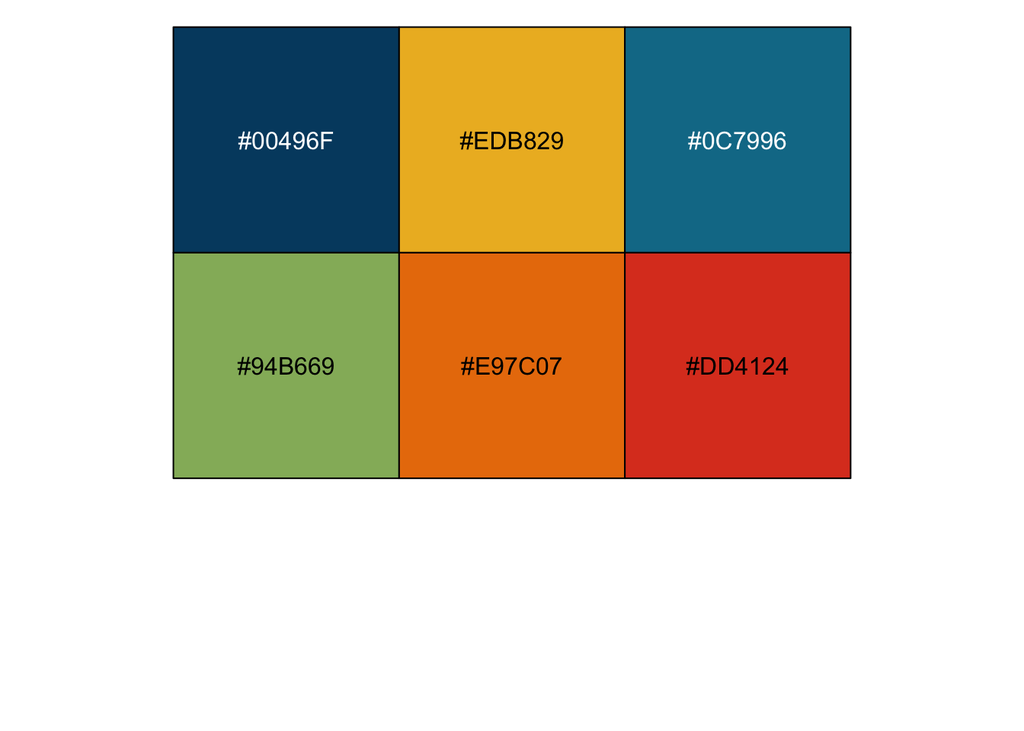

```r
#   #1         #3        #4       #2       #5         #6
#"#00496F" "#0C7996" "#94B669" "#EDB829" "#E97C07" "#DD4124"

#Need the following order
#"#00496F", "#EDB829", "#0C7996", "#94B669", "#E97C07", "#DD4124"

fig3.pal <- c("#00496F", "#EDB829", "#0C7996", "#94B669", "#E97C07", "#DD4124")
show_col(fig3.pal)
```

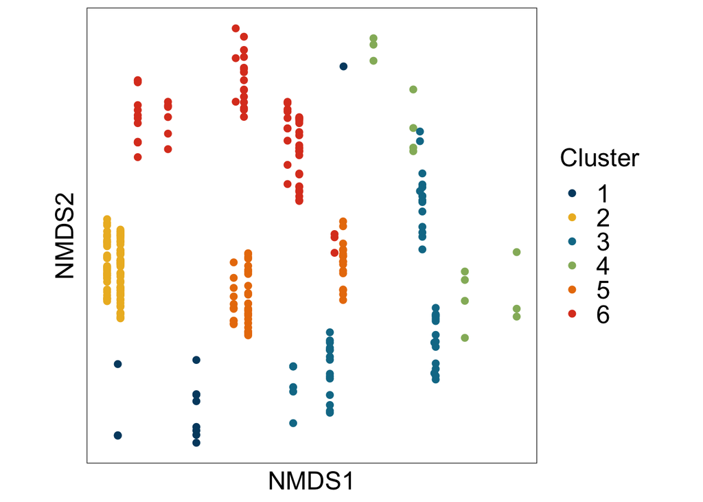

```r
#nMDS plot for the assessmenet of global change (yes/no) and the drivers.
#as.integer(unique(treatment.scores$adult.clust.num))
#treatment.scores$prob.clust.num = lapply(treatment.scores$prob.clust.num, as.factor)

trait_nMDS_prob_fig <- ggplot() +
  #geom_polygon(data=hull.data,
  #             aes(x=NMDS1, y=NMDS2,
  #                 fill= prob.clust.num,
  #                 group= prob.clust.num),
  #             alpha=0.30) + # add the convex hulls
  geom_point(data=treatment.scores,
             aes(x=NMDS1, y=NMDS2, colour=factor(prob.clust.num)),
             size=2,
             position = position_jitter(width = 0, height = 0.1, seed = 8)) + # add the point markers
  #geom_jitter(aes(x=NMDS1, y=NMDS2, colour=prob.clust.num))+
  coord_equal() +
  theme_bw()  +
  theme(axis.text.x = element_blank(),  # remove x-axis text
        axis.text.y = element_blank(), # remove y-axis text
        axis.ticks = element_blank(),  # remove axis ticks
        axis.title.x = element_text(size=18), # remove x-axis labels
        axis.title.y = element_text(size=18), # remove y-axis labels
        legend.title = element_text(size = 18),
        legend.text = element_text(size = 18),
        legend.justification = c(0,0.5),
        #panel.background = element_rect(fill = "lightgrey"),
        panel.grid.major = element_blank(),  #remove major-grid labels
        panel.grid.minor = element_blank(),  #remove minor-grid labels
        plot.background = element_blank()) +
  scale_colour_manual(values=fig3.pal, name="Cluster")

#  scale_colour_viridis(option="magma", begin = 0.8, end = 0.2, name = "Cluster Number") #+
  #scale_fill_viridis(option="magma", begin = 0.8, end = 0.2, name = "Cluster Number") #+

trait_nMDS_prob_fig
```

```r
ggsave(here("outputs_figures/clusters/prob_cluster_mar2022/div_hab/trait_nMDS_prob_clusters_div6_hab.png"), plot = trait_nMDS_prob_fig, width = 8, height = 8, dpi = 300)
```